# Projekt - Porządkowanie Liniowe & Analiza Skupień

Jakub Anczyk

2023-11-12

# Wstęp

W tej pracy spróbuję znaleźć optymalny produkt pod względem kaloryczności, zawartości białka, tłuszczu, tłuszczy nasyconych, błonnika i węglowodanów oraz dokonam analizy różnych produktów pod kątem wzajemnego podobieństwa. W analizy wykorzystam poznane techniki porządkowania liniowego oraz analizy skupień. Celem tej pracy będzie wyznaczenie produktu, który najlepiej nadaje się na podstawowy (główny) element składowy codziennej diety.

Ważne: **Dane pochodzą z gotowego zbioru danych zawierającego produkty dostępne na rynku amerykańskim, więc wyniki nie są doskonałe i nie należy się nimi sugerować w kształtowaniu własnych nawyków żywieniowych.**

# Część pierwsza: Porządkowanie liniowe

## Dane

Do projektu wybrałem zestaw danych dotyczący zawartości wartości odżywczych w różnego rodzaju produktach spożywczych, znaleziony na stronie [Kaggle](https://www.kaggle.com/code/niharika41298/food-nutrition-analysis-eda/input).

```r
data <- read.csv('nutrition.csv')
str(data)
```

```
## 'data.frame':    334 obs. of  10 variables:
##  $ Food    : chr  "Cows' milk" "Milk skim" "Buttermilk" "Evaporated, undiluted" ...
##  $ Measure : chr  "1 qt." "1 qt." "1 cup" "1 cup" ...
##  $ Grams   : int  976 984 246 252 1419 103 85 85 244 540 ...
##  $ Calories: int  660 360 127 345 1373 515 290 290 165 690 ...
##  $ Protein : chr  "32" "36" "9" "16" ...
##  $ Fat     : chr  "40" "t" "5" "20" ...
##  $ Sat.Fat : chr  "36" "t" "4" "18" ...
##  $ Fiber   : chr  "0" "0" "0" "0" ...
##  $ Carbs   : chr  "48" "52" "13" "24" ...
##  $ Category: chr  "Dairy products" "Dairy products" "Dairy products" "Dairy products" ...
```

## Przygotowanie danych

W celu przygotowania danych czyszczę je z elementów, które nie są liczbami, jak na przykład losowe litery lub symbole w komórkach. W zestawie zastosowano także literę “t” tam, gdzie wartości odżywcze w danym produkcie są śladowe (ang. “trace amounts”) - w tym przypadku zamieniam je wszystkie na zero.

Ograniczam też zestaw wyłącznie do produktów pochodzenia zwierzęcego, tj. mięsa, ryb i owoców morza aby łatwiej je było kategoryzować oraz dlatego, że pozostałe rodzaje produktów nie nadają się jako główny element diety, którego w tej analizie szukamy.

Ponieważ dane zostały przedstawione dla bardzo rozmaitych jednostek miary, obliczam je ponownie dla 100 gram każdego produktu i usuwam zbędne dane.

```r
columns_to_replace <- c('Grams','Calories','Protein','Fat','Sat.Fat','Fiber','Carbs')

data <- data %>%
  mutate_at(vars(all_of(columns_to_replace)), ~as.numeric(gsub("[^0-9.]", "", .))) %>%
  mutate_at(vars(all_of(columns_to_replace)), list(~coalesce(., 0))) %>%
  filter(Category == 'Fish, Seafood' | Category == 'Meat, Poultry') %>%
  select(-c('Measure', 'Category')) %>%
  distinct()

data <- data %>%
  mutate(Calories = Calories/Grams*100,
         Protein = Protein/Grams*100,
         Fat = Fat/Grams*100,
         Sat.Fat = Sat.Fat/Grams*100,
         Fiber = Fiber/Grams*100,
         Carbs = Carbs/Grams*100,
         Grams = 100) %>%
  select(-c('Grams'))

rownames(data) <- data[,1]
data <- data[,-1]
head(data)
```

```
##             Calories  Protein      Fat  Sat.Fat Fiber Carbs
## Salt pork   783.3333  5.00000 91.66667  0.00000     0  0.00
## Bacon       593.7500 25.00000 50.00000 43.75000     0  6.25
## Beef        288.2353 27.05882 18.82353 17.64706     0  0.00
## Hamburger   288.2353 24.70588 20.00000 17.64706     0  0.00
## Ground lean 217.6471 28.23529 11.76471 10.58824     0  0.00
## Roast beef  458.8235 18.82353 42.35294 41.17647     0  0.00
```

## Podstawowe statystyki

W celu dokonania podstawowej analizy statystyk danych w zestawie korzystam z funkcji descr() z biblioteki summarytools.

Jak widzimy wszystkie dane w zestawie po wyczyszczeniu są prawidłowe (nie ma wartości NA, NaN oraz null).

```r
(round(data, digits=2))
```

```
##                         Calories Protein   Fat Sat.Fat Fiber Carbs
## Salt pork                 783.33    5.00 91.67    0.00     0  0.00
## Bacon                     593.75   25.00 50.00   43.75     0  6.25
## Beef                      288.24   27.06 18.82   17.65     0  0.00
## Hamburger                 288.24   24.71 20.00   17.65     0  0.00
## Ground lean               217.65   28.24 11.76   10.59     0  0.00
## Roast beef                458.82   18.82 42.35   41.18     0  0.00
## Steak                     388.24   23.53 31.76   29.41     0  0.00
## Steak, lean, as round     258.82   28.24 14.12   12.94     0  0.00
## Corned beef               217.65   25.88 11.76   10.59     0  0.00
## Corned beef hash canned   141.18   14.12  9.41    8.24     0  7.06
## Corned beef hash Dried    205.36   33.93  7.14    7.14     0  0.00
## Pot-pie                   211.45    7.93 12.33   11.01     0 14.10
## Corned beef hash Stew      78.72    6.38  4.26    3.83     0  6.38
## chicken                   217.65   27.06 10.59    8.24     0  0.00
## chicken, fried            288.24   29.41 17.65   12.94     0  0.00
## Roasted chicken           290.00   25.00 20.00   16.00     0  0.00
## Chicken livers, fried     140.00   22.00 14.00   12.00     0  2.30
## Duck, domestic            370.00   16.00 28.00    0.00     0  0.00
## Lamb, chop, broiled       417.39   20.87 30.43   28.70     0  0.00
## Leg roasted               365.12   23.26 16.28   16.28     0  0.00
## Shoulder, braised         335.29   21.18 27.06   24.71     0  0.00
## Pork, chop, 1 thick       260.00   16.00 21.00   18.00     0  0.00
## Ham pan-broiled           341.18   18.82 25.88   22.35     0  0.00
## Ham, as                   298.25   22.81 22.81   19.30     0  0.00
## Ham, canned, spiced       289.47   14.04 24.56   21.05     0  1.75
## Pork roast                364.71   24.71 28.24   24.71     0  0.00
## Pork sausage              475.00   18.00 44.00   40.00     0  0.00
## Turkey                    265.00   27.00 15.00    0.00     0  0.00
## Veal                      217.65   27.06 10.59    9.41     0  0.00
## Roast                     358.82   15.29 16.47   15.29     0  0.00
## Clams                     102.35   14.12  1.18    0.00     0  2.35
## Cod                       170.00   28.00  5.00    0.00     0  0.00
## Crab meat                 105.88   16.47  2.35    0.00     0  1.18
## Fish sticks fried         178.57   16.96  8.93    4.46     0  7.14
## Flounder                  200.00   30.00  8.00    0.00     0  0.00
## Haddock                   158.82   18.82  5.88    4.71     0  7.06
## Halibut                   182.00   26.00  8.00    0.00     0  0.00
## Herring                   211.00   22.00 13.00    0.00     0  0.00
## Lobster                    92.00   18.00  1.00    0.00     0  0.00
## Mackerel                  182.35   21.18 10.59    0.00     0  0.00
## Oyster stew               147.06   22.35  7.06    1.18     0  0.00
## Salmon                    141.18   20.00  5.88    1.18     0  0.00
## Sardines                  211.76   25.88 10.59    4.71     0  0.00
## Scallops                  104.00   18.00  8.00    0.00     0 10.00
## Shad                      200.00   23.53 11.76    0.00     0  0.00
## Shrimp                    129.41   27.06  1.18    0.00     0  0.00
## Swordfish                 180.00   27.00  6.00    0.00     0  0.00
## Tuna                      200.00   29.41  8.24    3.53     0  0.00
```

```r
descr(data)
```

```
## Descriptive Statistics
## data
## N: 48
##
##                     Calories    Carbs      Fat    Fiber   Protein   Sat.Fat
## ----------------- ---------- -------- -------- -------- --------- ---------
##              Mean     256.70     1.37    17.10     0.00     21.71     10.89
##           Std.Dev     134.60     3.11    15.70     0.00      6.26     11.88
##               Min      78.72     0.00     1.00     0.00      5.00      0.00
##                Q1     174.29     0.00     8.00     0.00     18.00      0.00
##            Median     217.65     0.00    12.05     0.00     22.58      8.24
##                Q3     316.77     0.00    21.90     0.00     27.00     17.65
##               Max     783.33    14.10    91.67     0.00     33.93     43.75
##               MAD     105.57     0.00     9.06     0.00      6.64     12.21
##               IQR     131.08     0.00    13.45     0.00      9.00     17.65
##                CV       0.52     2.28     0.92      NaN      0.29      1.09
##          Skewness       1.56     2.37     2.51      NaN     -0.68      1.08
##       SE.Skewness       0.34     0.34     0.34     0.34      0.34      0.34
##          Kurtosis       3.35     5.09     8.51      NaN      0.13      0.44
##           N.Valid      48.00    48.00    48.00    48.00     48.00     48.00
##         Pct.Valid     100.00   100.00   100.00   100.00    100.00    100.00
```

### Kalorie

Produkty z wybranych kategorii zawierają średnio 256.70 kcal przy medianie 217.65 kcal, co oznacza, że w zestawie znajdują się wartości skrajne, silnie wpływające na wartość średniej. Potwierdza to wartość statystyki Max na poziomie 783.33 kcal / 100 g.

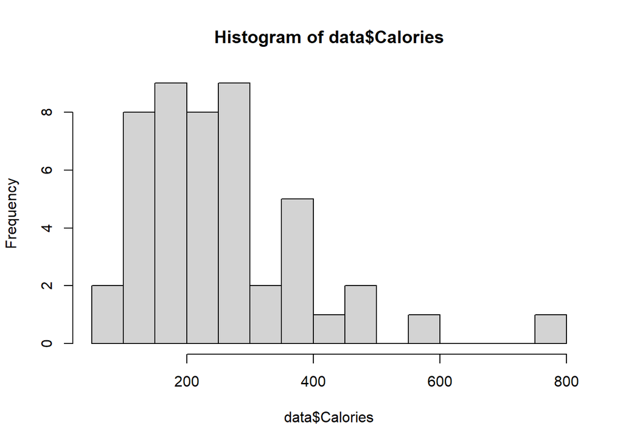

```r
hist(data$Calories, n=20)
```

### Węglowodany

Węglowodany w tej kategorii produktów są na niskim poziomie, co nie jest zaskoczeniem, bowiem zgodnie z tradycyjną wiedzą mięso, ryby i owoce morza to w głównej mierze białka i tłuszcze, raczej ubogie w węglowodany, które znajdują się głównie w produktach pochodzenia roślinnego.

Przykładem wartości skrajnej jest w tym przypadku tzw. “Pot-pie”, które jest w istocie rodzajem ciasta, choć rzeczywiście zawiera także mięso - poziom węglowodanów wynosi w tym przypadku 14.1 g / 100g. Umieszczenie tej potrawy w wybranych kategoriach może być dyskusyjne.

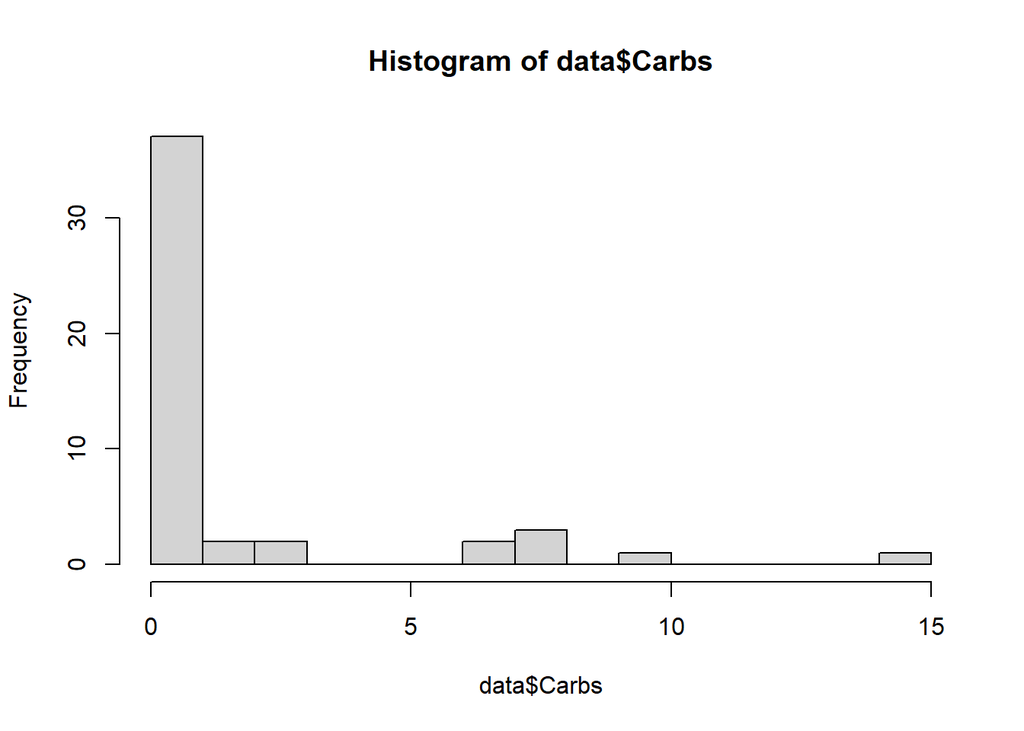

```r
hist(data$Carbs, n=20)
```

### Tłuszcze

Z kolei wartości tłuszczy rozmieszczone są wokół wartości 17.10g / 100g z nieco wyższą wartością kurtozy niż w przypadku kalorii. Wartością mocno odstającą jest “salt-pork”, czyli rodzaj wieprzowiny peklowanej solą, z zawartością tłuszczu na poziomie 91.67%.

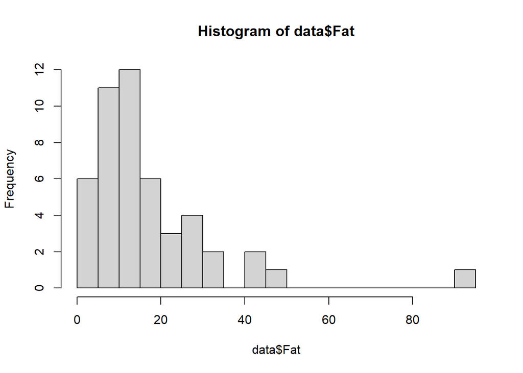

```r
hist(data$Fat, n=20)
```

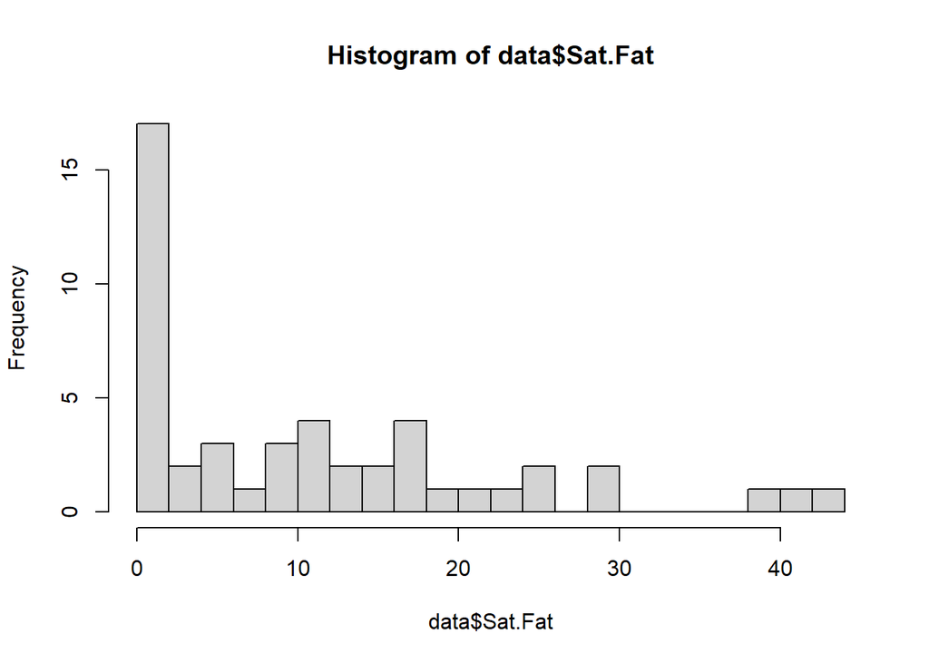

```r
hist(data$Sat.Fat, n=20)
```

### Błonnik

Błonnik, którego w mięsach jest zazwyczaj niewiele, wynosi dla każdej pozycji 0 lub t (śladowe ilości). W związku z tym usuwam tę zmienną z zestawu danych.

```r
sum(data$Fiber)
```

```
## [1] 0
```

```r
data <- data[,-5]
```

### Białko

Najbardziej interesującym składnikiem w pożywieniu jest jednak białko. Tutaj kurtoza wynosi jedynie 0.13, a więc rozkład zawartości białka jest zbliżony do rozkładu normalnego.

Zdecydowanie najwięcej białka, bo aż 33.93 zawiera suszona wołowina. Wynika to prawdopodobnie z faktu, że ususzona zawiera mniej wody, która najbardziej zwiększa wagę produktu. Pozwala to na duże zwiększenie procentowej zawartości białka w produkcie - niestety podobnie jest w przypadku kaloryczności.

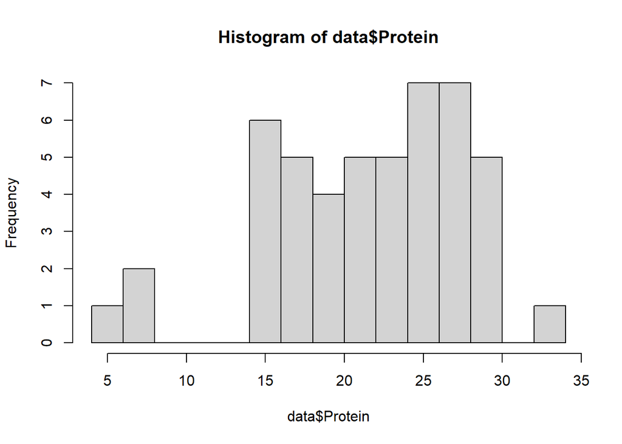

```r
hist(data$Protein, n=20)
```

## Klasyfikacja danych

Następnie klasyfikuję dane na stymulanty, nominanty i destymulanty oraz zamieniam je na stymulanty dla dalszej analizy.

Jako stymulantę klasyfikuję białko, ponieważ jest to kluczowy w mojej diecie element, którego nie sposób przedawkować i najlepiej zażywać go w dużych ilościach w połączeniu z wysiłkiem fizycznym.

Jako destymulanty oceniam tłuszcze nasycone, kalorie i węglowodany, ponieważ zażywanie pierwszej pozycji jest uznane za niezdrowe a kolejne dwie mogą być dostarczone organizmowi z powodzeniem innym produktem, takim jak ryż lub ziemniaki.

Nominanta w zestawie jest jedna: są nią tłuszcze i określam ich optymalną wartość na 20g (lub na 20%). Wynika to z faktu, że tłuszcze obok białka są jednym z ważniejszych dla zdrowia składników odżywczych, szczególnie w przypadku osób aktywnych fizycznie - mają kluczowe znaczenie w regeneracji stawów i stabilizacji gospodarki hormonalnej.

```r
st <- c('Protein')
dst <- c('Calories','Sat.Fat', 'Carbs')
nom <- c('Fat')

edit_data <- data

for(i in 1:nrow(edit_data)){
  if(edit_data[i, nom] == 20){edit_data[i, nom] = 1}
  else if(edit_data[i, nom] < 20){edit_data[i, nom] = -1/(edit_data[i, nom]-20-1)}
  else{edit_data[i, nom] = 1/(edit_data[i, nom]-20+1)}
}

edit_data$Calories <- -1*edit_data$Calories
edit_data$Sat.Fat <- -1*edit_data$Sat.Fat
edit_data$Carbs <- -1*edit_data$Carbs

(round(edit_data, digits=2))
```

```
##                         Calories Protein  Fat Sat.Fat  Carbs
## Salt pork                -783.33    5.00 0.01    0.00   0.00
## Bacon                    -593.75   25.00 0.03  -43.75  -6.25
## Beef                     -288.24   27.06 0.46  -17.65   0.00
## Hamburger                -288.24   24.71 1.00  -17.65   0.00
## Ground lean              -217.65   28.24 0.11  -10.59   0.00
## Roast beef               -458.82   18.82 0.04  -41.18   0.00
## Steak                    -388.24   23.53 0.08  -29.41   0.00
## Steak, lean, as round    -258.82   28.24 0.15  -12.94   0.00
## Corned beef              -217.65   25.88 0.11  -10.59   0.00
## Corned beef hash canned  -141.18   14.12 0.09   -8.24  -7.06
## Corned beef hash Dried   -205.36   33.93 0.07   -7.14   0.00
## Pot-pie                  -211.45    7.93 0.12  -11.01 -14.10
## Corned beef hash Stew     -78.72    6.38 0.06   -3.83  -6.38
## chicken                  -217.65   27.06 0.10   -8.24   0.00
## chicken, fried           -288.24   29.41 0.30  -12.94   0.00
## Roasted chicken          -290.00   25.00 1.00  -16.00   0.00
## Chicken livers, fried    -140.00   22.00 0.14  -12.00  -2.30
## Duck, domestic           -370.00   16.00 0.11    0.00   0.00
## Lamb, chop, broiled      -417.39   20.87 0.09  -28.70   0.00
## Leg roasted              -365.12   23.26 0.21  -16.28   0.00
## Shoulder, braised        -335.29   21.18 0.12  -24.71   0.00
## Pork, chop, 1 thick      -260.00   16.00 0.50  -18.00   0.00
## Ham pan-broiled          -341.18   18.82 0.15  -22.35   0.00
## Ham, as                  -298.25   22.81 0.26  -19.30   0.00
## Ham, canned, spiced      -289.47   14.04 0.18  -21.05  -1.75
## Pork roast               -364.71   24.71 0.11  -24.71   0.00
## Pork sausage             -475.00   18.00 0.04  -40.00   0.00
## Turkey                   -265.00   27.00 0.17    0.00   0.00
## Veal                     -217.65   27.06 0.10   -9.41   0.00
## Roast                    -358.82   15.29 0.22  -15.29   0.00
## Clams                    -102.35   14.12 0.05    0.00  -2.35
## Cod                      -170.00   28.00 0.06    0.00   0.00
## Crab meat                -105.88   16.47 0.05    0.00  -1.18
## Fish sticks fried        -178.57   16.96 0.08   -4.46  -7.14
## Flounder                 -200.00   30.00 0.08    0.00   0.00
## Haddock                  -158.82   18.82 0.07   -4.71  -7.06
## Halibut                  -182.00   26.00 0.08    0.00   0.00
## Herring                  -211.00   22.00 0.12    0.00   0.00
## Lobster                   -92.00   18.00 0.05    0.00   0.00
## Mackerel                 -182.35   21.18 0.10    0.00   0.00
## Oyster stew              -147.06   22.35 0.07   -1.18   0.00
## Salmon                   -141.18   20.00 0.07   -1.18   0.00
## Sardines                 -211.76   25.88 0.10   -4.71   0.00
## Scallops                 -104.00   18.00 0.08    0.00 -10.00
## Shad                     -200.00   23.53 0.11    0.00   0.00
## Shrimp                   -129.41   27.06 0.05    0.00   0.00
## Swordfish                -180.00   27.00 0.07    0.00   0.00
## Tuna                     -200.00   29.41 0.08   -3.53   0.00
```

## Standaryzacja

W kolejnym kroku dokonuję standaryzacji danych…

```r
data_st <- as.data.frame(scale(edit_data))
(round(data_st, digits=2))
```

```
##                         Calories Protein   Fat Sat.Fat Carbs
## Salt pork                  -3.91   -2.67 -0.70    0.92  0.44
## Bacon                      -2.50    0.53 -0.61   -2.77 -1.57
## Beef                       -0.23    0.85  1.51   -0.57  0.44
## Hamburger                  -0.23    0.48  4.19   -0.57  0.44
## Ground lean                 0.29    1.04 -0.23    0.03  0.44
## Roast beef                 -1.50   -0.46 -0.56   -2.55  0.44
## Steak                      -0.98    0.29 -0.38   -1.56  0.44
## Steak, lean, as round      -0.02    1.04 -0.05   -0.17  0.44
## Corned beef                 0.29    0.67 -0.23    0.03  0.44
## Corned beef hash canned     0.86   -1.21 -0.34    0.22 -1.83
## Corned beef hash Dried      0.38    1.95 -0.41    0.32  0.44
## Pot-pie                     0.34   -2.20 -0.20   -0.01 -4.09
## Corned beef hash Stew       1.32   -2.45 -0.48    0.59 -1.61
## chicken                     0.29    0.85 -0.30    0.22  0.44
## chicken, fried             -0.23    1.23  0.71   -0.17  0.44
## Roasted chicken            -0.25    0.53  4.19   -0.43  0.44
## Chicken livers, fried       0.87    0.05 -0.06   -0.09 -0.30
## Duck, domestic             -0.84   -0.91 -0.22    0.92  0.44
## Lamb, chop, broiled        -1.19   -0.13 -0.34   -1.50  0.44
## Leg roasted                -0.81    0.25  0.28   -0.45  0.44
## Shoulder, braised          -0.58   -0.09 -0.16   -1.16  0.44
## Pork, chop, 1 thick        -0.02   -0.91  1.71   -0.60  0.44
## Ham pan-broiled            -0.63   -0.46 -0.05   -0.96  0.44
## Ham, as                    -0.31    0.18  0.53   -0.71  0.44
## Ham, canned, spiced        -0.24   -1.23  0.12   -0.86 -0.12
## Pork roast                 -0.80    0.48 -0.23   -1.16  0.44
## Pork sausage               -1.62   -0.59 -0.57   -2.45  0.44
## Turkey                     -0.06    0.85  0.05    0.92  0.44
## Veal                        0.29    0.85 -0.30    0.12  0.44
## Roast                      -0.76   -1.03  0.32   -0.37  0.44
## Clams                       1.15   -1.21 -0.52    0.92 -0.32
## Cod                         0.64    1.01 -0.46    0.92  0.44
## Crab meat                   1.12   -0.84 -0.51    0.92  0.06
## Fish sticks fried           0.58   -0.76 -0.36    0.54 -1.86
## Flounder                    0.42    1.32 -0.39    0.92  0.44
## Haddock                     0.73   -0.46 -0.44    0.52 -1.83
## Halibut                     0.55    0.69 -0.39    0.92  0.44
## Herring                     0.34    0.05 -0.15    0.92  0.44
## Lobster                     1.22   -0.59 -0.52    0.92  0.44
## Mackerel                    0.55   -0.09 -0.30    0.92  0.44
## Oyster stew                 0.81    0.10 -0.42    0.82  0.44
## Salmon                      0.86   -0.27 -0.44    0.82  0.44
## Sardines                    0.33    0.67 -0.30    0.52  0.44
## Scallops                    1.13   -0.59 -0.39    0.92 -2.78
## Shad                        0.42    0.29 -0.23    0.92  0.44
## Shrimp                      0.95    0.85 -0.52    0.92  0.44
## Swordfish                   0.57    0.85 -0.44    0.92  0.44
## Tuna                        0.42    1.23 -0.38    0.62  0.44
```

## Model

…oraz tworzę wzorzec (model) w oparciu o maksymalne wartości standaryzowanych wartości dla każdej kolumny.

```r
model <- c(max(data_st[,"Calories"]),
           max(data_st[,"Protein"]),
           max(data_st[,"Fat"]),
           max(data_st[,"Sat.Fat"]),
           max(data_st[,"Carbs"]))
```

## Odległość od modelu

W celu przystąpienia do finalnych kroków analizy obliczam odległość każdej wartości w zestawie od odpowiadającego jej wzorca.

```r
distance <- data_st

for(i in 1:nrow(data_st)){
  distance[i,] <- (data_st[i,]-model)^2
}

distance$distsum <- rowSums(distance)
distance$distsum <- sqrt(distance$distsum)
```

## Miara Hellwiga

W ostatnim kroku wyznaczam miarę Hellwiga dla każdej pozycji w zestawie danych.

```r
d0 <- mean(distance$distsum) + 2 * sd(distance$distsum)

HELLWIG <- data.frame(food = rownames(data_st),
                      measure = 1-distance$distsum/d0)
```

## Podsumowanie i wyniki porządkowania liniowego

Według posortowanych wartości miary Hellwiga, optymalnym wyborem pod kątem wartości odżywczych i zawartości białka jest (bez większego zaskoczenia) pieczony kurczak!

```r
HELLWIG[order(HELLWIG$measure, decreasing = TRUE), ]
```

```
##                       food      measure
## 16         Roasted chicken  0.665254233
## 4                Hamburger  0.652561942
## 3                     Beef  0.519328790
## 15          chicken, fried  0.463159730
## 22     Pork, chop, 1 thick  0.427525138
## 28                  Turkey  0.401011840
## 8    Steak, lean, as round  0.378476581
## 24                Ham, as   0.377643353
## 35                Flounder  0.372931402
## 5              Ground lean  0.371770942
## 48                    Tuna  0.370800929
## 11  Corned beef hash Dried  0.369305229
## 14                 chicken  0.363296327
## 43                Sardines  0.362788954
```

[output cut: 34 more lines]

```r
data[16,]
```

```
##                 Calories Protein Fat Sat.Fat Carbs
## Roasted chicken      290      25  20      16     0
```

Widzimy zatem wyraźnie, ze algorytm poszedł na pewien kompromis, i wybrał produkt o możliwie najlepszym składzie, choć jedna ze zmiennych leży poza zakresem, który nazwalibyśmy idealnym.

Jeżeli jest to dla nas nie do przyjęcia, to na pewno ucieszy nas fakt, że na drugim miejscu znalazła się pozycja o nazwie “hamburger”:

```r
data[4,]
```

```
##           Calories  Protein Fat  Sat.Fat Carbs
## Hamburger 288.2353 24.70588  20 17.64706     0
```

Przyjęcie oczekiwanego poziomu tłuszczu na poziomie 20g na 100g danego produktu jest niewątpliwie czynnikiem, który najbardziej zaważył na ostatecznych wynikach analizy.

Gdyby przyjąć, że zmienna “Fat” jest destymulantą, wśród preferowanych produktów prawdopodobnie znajdą się ryby lub owoce morza.

Możemy to szybko sprawdzić, powtarzając analizę w ten sposób:

```r
st <- c('Protein')
dst <- c('Calories','Sat.Fat', 'Carbs', 'Fat')

edit_data_2 <- data

edit_data_2$Fat <- -1*edit_data_2$Fat
edit_data_2$Calories <- -1*edit_data_2$Calories
edit_data_2$Sat.Fat <- -1*edit_data_2$Sat.Fat
edit_data_2$Carbs <- -1*edit_data_2$Carbs

data_st_2 <- as.data.frame(scale(edit_data_2))

model_2 <- c(max(data_st_2[,"Calories"]),
           max(data_st_2[,"Protein"]),
           max(data_st_2[,"Fat"]),
           max(data_st_2[,"Sat.Fat"]),
           max(data_st_2[,"Carbs"]))


distance_2 <- data_st_2

for(i in 1:nrow(data_st_2)){
  distance_2[i,] <- (data_st_2[i,]-model_2)^2
}

distance_2$distsum <- rowSums(distance_2)
distance_2$distsum <- sqrt(distance_2$distsum)

d0 <- mean(distance_2$distsum) + 2 * sd(distance_2$distsum)

HELLWIG_2 <- data.frame(food = rownames(data_st_2),
                      measure = 1-distance_2$distsum/d0)

HELLWIG_2[order(HELLWIG_2$measure, decreasing = TRUE), ]
```

```
##                       food     measure
## 46                  Shrimp  0.81947526
## 11  Corned beef hash Dried  0.81599617
## 35                Flounder  0.81564963
## 32                     Cod  0.81450166
## 48                    Tuna  0.80121171
## 47               Swordfish  0.78597350
## 37                 Halibut  0.75939985
## 14                 chicken  0.72510047
## 5              Ground lean  0.72363677
## 43                Sardines  0.72350301
## 29                    Veal  0.71870639
## 41             Oyster stew  0.69527599
## 28                  Turkey  0.69140081
## 9              Corned beef  0.68959949
```

[output cut: 34 more lines]

```r
data[46,]
```

```
##        Calories  Protein      Fat Sat.Fat Carbs
## Shrimp 129.4118 27.05882 1.176471       0     0
```

# Część druga: Analiza skupień

W drugiej części zajmę się analizą skupień. Będę w dalszym ciągu korzystał z zestawu danych, który przygotowałem na potrzeby pierwszej części projektu.

```r
data <- read.csv('nutrition_cleaned.csv',row.names = 1)
str(data)
```

```
## 'data.frame':    48 obs. of  5 variables:
##  $ Calories: num  783 594 288 288 218 ...
##  $ Protein : num  5 25 27.1 24.7 28.2 ...
##  $ Fat     : num  91.7 50 18.8 20 11.8 ...
##  $ Sat.Fat : num  0 43.8 17.6 17.6 10.6 ...
##  $ Carbs   : num  0 6.25 0 0 0 ...
```

## Analiza współczynników zmienności

Wszystkie atrybuty wykazują pożądaną zmienność na poziomie większym niż 10% (najmniejsza zmienność na poziomie 28.82% występuje w przypadku białka).

```r
data.frame(variable = colnames(data),
           coeff_var = c(sd(data$Calories)/mean(data$Calories),
                         sd(data$Protein)/mean(data$Protein),
                         sd(data$Fat)/mean(data$Fat),
                         sd(data$Sat.Fat)/mean(data$Sat.Fat),
                         sd(data$Carbs)/mean(data$Carbs)))
```

```
##   variable coeff_var
## 1 Calories 0.5243465
## 2  Protein 0.2882311
## 3      Fat 0.9182032
## 4  Sat.Fat 1.0913020
## 5    Carbs 2.2773041
```

## Analiza korelacji

```r
data <- data[,-1]
round(cor(data),3)
```

```
##         Protein    Fat Sat.Fat  Carbs
## Protein   1.000 -0.306   0.002 -0.495
## Fat      -0.306  1.000   0.550 -0.120
## Sat.Fat   0.002  0.550   1.000 -0.042
## Carbs    -0.495 -0.120  -0.042  1.000
```

Po dokonaniu tej modyfikacji widzimy, że wzajemne korelacje między zmiennymi są na prawidłowym poziomie.

## Standaryzacja

Przed dalszą analizą dokonuję szybkiej standaryzacji danych.

```r
data_st <- as.data.frame(scale(data))
(round(head(data_st), 2))
```

```
##             Protein   Fat Sat.Fat Carbs
## Salt pork     -2.67  4.75   -0.92 -0.44
## Bacon          0.53  2.10    2.77  1.57
## Beef           0.85  0.11    0.57 -0.44
## Hamburger      0.48  0.19    0.57 -0.44
## Ground lean    1.04 -0.34   -0.03 -0.44
## Roast beef    -0.46  1.61    2.55 -0.44
```

## Grupowanie przedziałowe metodą k-średnich

```r
gr2 <- kmeans(x = data_st, centers=2, nstart=20)
gr2$cluster
```

```
##               Salt pork                   Bacon                    Beef
##                       2                       2                       1
##               Hamburger             Ground lean              Roast beef
##                       1                       1                       2
##                   Steak   Steak, lean, as round             Corned beef
##                       2                       1                       1
## Corned beef hash canned  Corned beef hash Dried                 Pot-pie
##                       1                       1                       1
##   Corned beef hash Stew                 chicken          chicken, fried
##                       1                       1                       1
##         Roasted chicken   Chicken livers, fried          Duck, domestic
##                       1                       1                       1
##     Lamb, chop, broiled             Leg roasted       Shoulder, braised
##                       2                       1                       2
##     Pork, chop, 1 thick         Ham pan-broiled                Ham, as
##                       2                       2                       2
##     Ham, canned, spiced              Pork roast            Pork sausage
##                       2                       2                       2
##                  Turkey                    Veal                   Roast
##                       1                       1                       1
##                   Clams                     Cod               Crab meat
##                       1                       1                       1
##       Fish sticks fried                Flounder                 Haddock
##                       1                       1                       1
##                 Halibut                 Herring                 Lobster
##                       1                       1                       1
##                Mackerel             Oyster stew                  Salmon
##                       1                       1                       1
##                Sardines                Scallops                    Shad
##                       1                       1                       1
##                  Shrimp               Swordfish                    Tuna
##                       1                       1                       1
```

```r
data$gr2 <- as.factor(gr2$cluster)
describeBy(data[,-5], group = data$gr2)
```

```
##
##  Descriptive statistics by group
## group: 1
##         vars  n  mean   sd median trimmed  mad  min   max range  skew kurtosis
## Protein    1 36 22.59 6.29  24.12   23.05 5.93 6.38 33.93 27.55 -0.70    -0.11
## Fat        2 36 10.58 5.97  10.59   10.32 5.23 1.00 28.00 27.00  0.58     0.29
## Sat.Fat    3 36  5.82 6.21   4.15    5.27 6.15 0.00 17.65 17.65  0.55    -1.22
## Carbs      4 36  1.60 3.42   0.00    0.88 0.00 0.00 14.10 14.10  2.10     3.63
##           se
## Protein 1.05
## Fat     1.00
## Sat.Fat 1.04
## Carbs   0.57
## ------------------------------------------------------------
## group: 2
##         vars  n  mean    sd median trimmed  mad min   max range  skew kurtosis
## Protein    1 12 19.06  5.58  19.85   19.88 4.92   5 25.00 20.00 -1.15     0.67
## Fat        2 12 36.65 19.58  29.34   32.71 8.38  21 91.67 70.67  1.76     2.30
## Sat.Fat    3 12 26.10 12.01  24.71   26.94 7.50   0 43.75 43.75 -0.34    -0.37
## Carbs      4 12  0.67  1.83   0.00    0.18 0.00   0  6.25  6.25  2.35     4.26
##           se
## Protein 1.61
## Fat     5.65
## Sat.Fat 3.47
## Carbs   0.53
```

Na wykresie widzimy wyraźnie, że algorytm poprawnie zidentyfikował dwie główne grupy zbiorze danych.

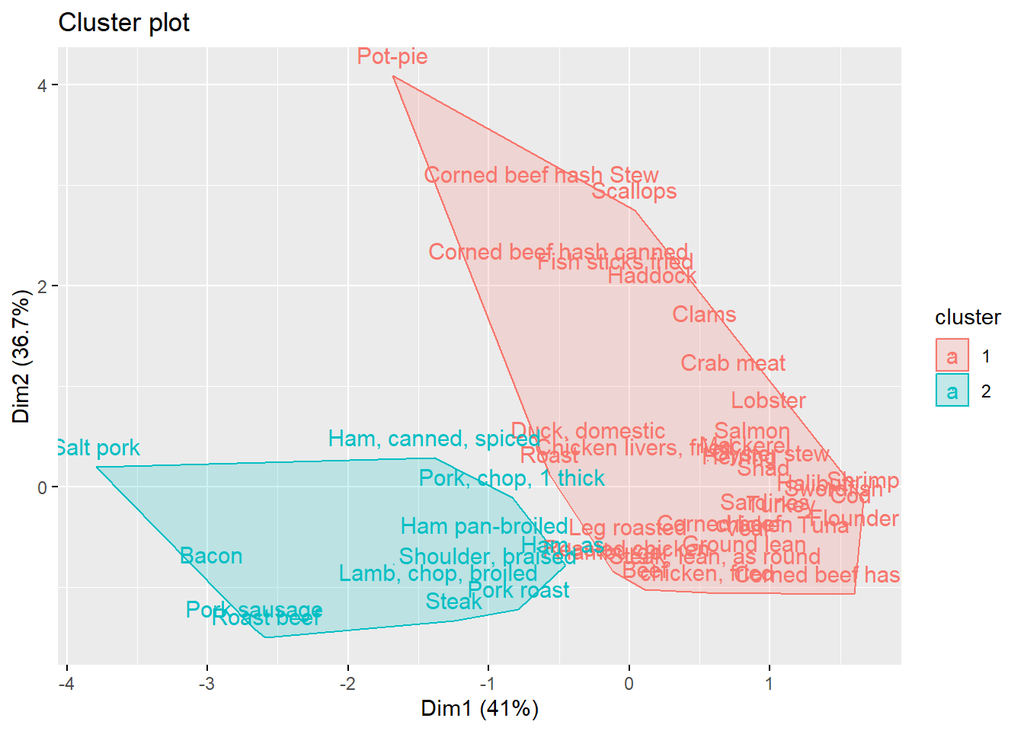

```r
fviz_cluster(gr2, data[,1:4], geom = "text")
```

Poniżej znajdują się przykładowe wykresy dla więcej niż 2 klastrów.

```r
gr3 <- kmeans(x = data_st, centers=3, nstart=20)
data$gr3 <- as.factor(gr3$cluster)
fviz_cluster(gr3, data[,1:4], geom = "text")
```

[output not shown]

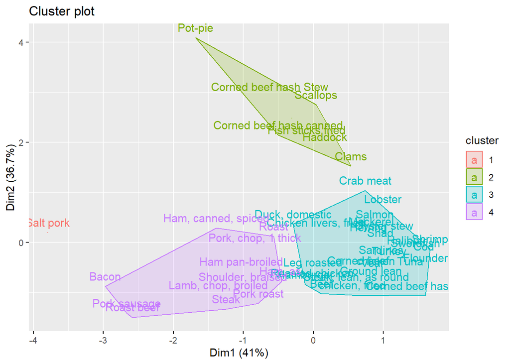

```r
gr4 <- kmeans(x = data_st, centers=4, nstart=20)
data$gr4 <- as.factor(gr4$cluster)
fviz_cluster(gr4, data[,1:4], geom = "text")
```

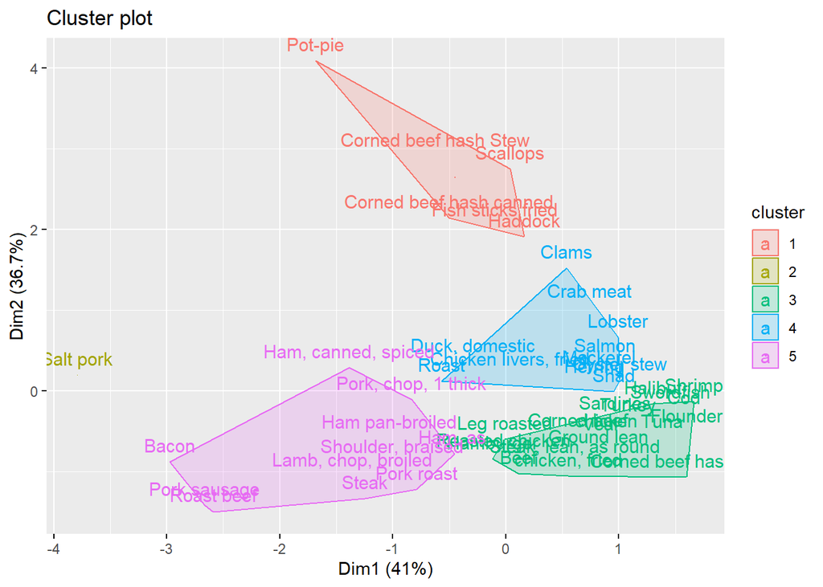

```r
gr5 <- kmeans(x = data_st, centers=5, nstart=20)
data$gr5 <- as.factor(gr5$cluster)
fviz_cluster(gr5, data[,1:4], geom = "text")
```

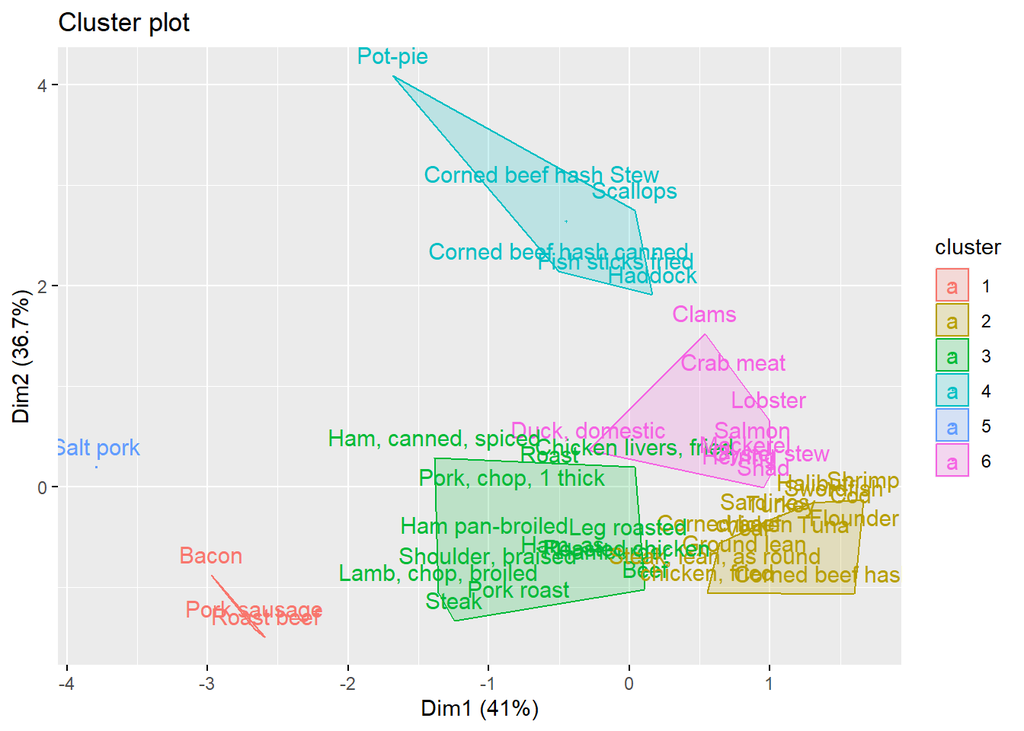

```r
gr6 <- kmeans(x = data_st, centers=6, nstart=20)
data$gr6 <- as.factor(gr6$cluster)
fviz_cluster(gr6, data[,1:4], geom = "text")
```

Możemy zauważyć, że już przy czterech klastrach klasyfikacja przestaje być poprawna. Powstaje bowiem klaster złożony wyłącznie z jednej obserwacji, czego przyczyną jest znaczne oddalenie wartości tłuszczy dla tej jednej obserwacji od reszty obserwacji w klastrze pierwszym.

```r
describeBy(data[,1:4], group = data$gr4)
```

```
##
##  Descriptive statistics by group
## group: 1
##         vars n  mean sd median trimmed mad   min   max range skew kurtosis se
## Protein    1 1  5.00 NA   5.00    5.00   0  5.00  5.00     0   NA       NA NA
## Fat        2 1 91.67 NA  91.67   91.67   0 91.67 91.67     0   NA       NA NA
## Sat.Fat    3 1  0.00 NA   0.00    0.00   0  0.00  0.00     0   NA       NA NA
## Carbs      4 1  0.00 NA   0.00    0.00   0  0.00  0.00     0   NA       NA NA
## ------------------------------------------------------------
## group: 2
##         vars n  mean   sd median trimmed  mad  min   max range  skew kurtosis
## Protein    1 7 13.76 4.87  14.12   13.76 5.76 6.38 18.82 12.44 -0.45    -1.68
## Fat        2 7  7.14 3.69   8.00    7.14 3.14 1.18 12.33 11.16 -0.23    -1.37
## Sat.Fat    3 7  4.61 4.03   4.46    4.61 5.59 0.00 11.01 11.01  0.25    -1.50
## Carbs      4 7  7.73 3.60   7.06    7.73 1.00 2.35 14.10 11.74  0.34    -0.86
##           se
## Protein 1.84
## Fat     1.39
## Sat.Fat 1.52
## Carbs   1.36
## ------------------------------------------------------------
## group: 3
##         vars  n  mean   sd median trimmed  mad min   max range  skew kurtosis
## Protein    1 28 25.06 4.19  25.94   25.22 3.49  16 33.93 17.93 -0.43    -0.25
## Fat        2 28 11.23 6.20  10.59   11.01 5.23   1 28.00 27.00  0.52     0.10
## Sat.Fat    3 28  5.79 6.54   2.35    5.28 3.49   0 17.65 17.65  0.55    -1.34
## Carbs      4 28  0.12 0.48   0.00    0.00 0.00   0  2.30  2.30  3.67    12.80
##           se
## Protein 0.79
## Fat     1.17
## Sat.Fat 1.24
## Carbs   0.09
## ------------------------------------------------------------
## group: 4
##         vars  n  mean    sd median trimmed  mad   min   max range  skew
## Protein    1 12 19.92  3.69  19.85   20.00 4.92 14.04 25.00 10.96 -0.10
## Fat        2 12 30.38 10.11  27.65   29.81 6.64 16.47 50.00 33.53  0.61
## Sat.Fat    3 12 27.37  9.55  24.71   26.94 7.50 15.29 43.75 28.46  0.53
## Carbs      4 12  0.67  1.83   0.00    0.18 0.00  0.00  6.25  6.25  2.35
##         kurtosis   se
## Protein    -1.50 1.07
## Fat        -0.98 2.92
## Sat.Fat    -1.30 2.76
## Carbs       4.26 0.53
```

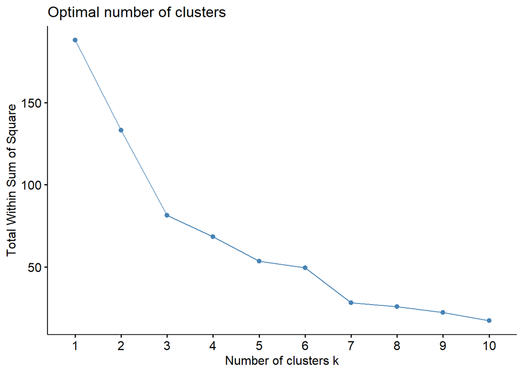

```r
fviz_nbclust(data_st, kmeans, method = "wss")
```

```r
fviz_cluster(gr3, data[,1:4], geom = "text")
```

[output not shown]

## Grupowanie hierarchiczne metodą Warda

W celu pogrupowania obserwacji wyznaczam w pierwszym kroku macierz wzajemnych odległości (metodą euklidesową), następnie grupuję je metodą Warda i generuję wizualizację w formie dendrogramu:

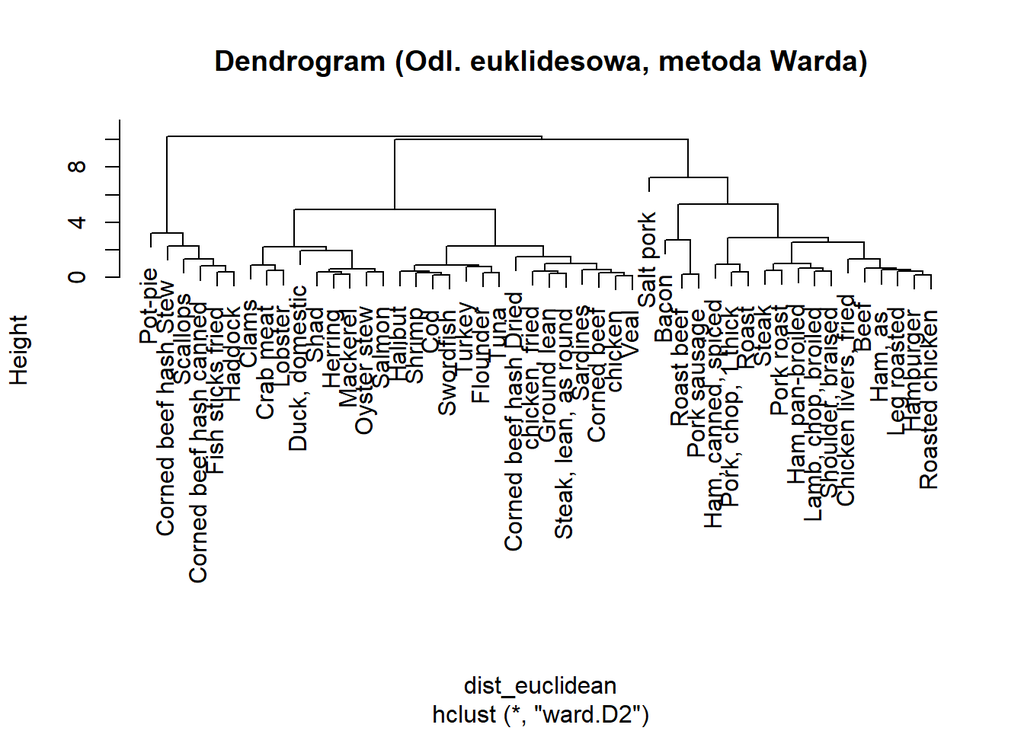

```r
dist_euclidean <- dist(data_st, method="euclidean")
ward_euclidean <- hclust(dist_euclidean, method="ward.D2")
plot(ward_euclidean, main="Dendrogram (Odl. euklidesowa, metoda Warda)")
```

Bazując na wykresie kolejnych odległości euklidesowej, widzimy także, że podział w miejscu trzech klastrów wydaje się być najbardziej optymalnym - odległości euklidesowe między pozostałymi ilościami klastrów są raczej zbliżone do siebie.

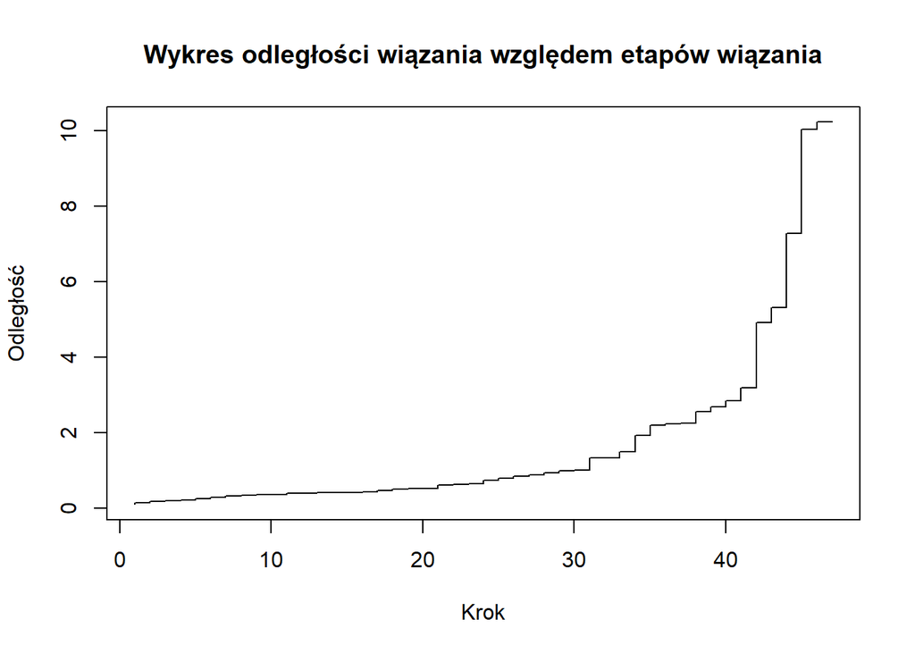

```r
plot(x=1:47, y= ward_euclidean$height, type="S",
     xlab="Krok", ylab="Odległość",
     main = "Wykres odległości wiązania względem etapów wiązania")
```

## Podsumowanie

Przy optymalnej ilości trzech klastrów dane zostają podzielone na trzy konkretne grupy:

**Grupa 1**: Zawiera przede wszystkim mięso wieprzowe, wołowinę i baraninę, ale ale także wysoko przetworzone rodzaje mięsa sprzedawane w puszkach.

```r
describeBy(data[,1:6], group = data$gr3)
```

```
##
##  Descriptive statistics by group
## group: 1
##         vars  n  mean    sd median trimmed  mad   min   max range  skew
## Protein    1 13 18.77  5.44  18.82   19.46 5.23  5.00 25.00 20.00 -1.02
## Fat        2 13 35.09 19.56  28.24   31.65 8.05 16.47 91.67 75.20  1.76
## Sat.Fat    3 13 25.26 11.88  24.71   25.88 8.02  0.00 43.75 43.75 -0.19
## Carbs      4 13  0.62  1.76   0.00    0.16 0.00  0.00  6.25  6.25  2.50
## gr2*       5 13  1.92  0.28   2.00    2.00 0.00  1.00  2.00  1.00 -2.82
## gr3*       6 13  1.00  0.00   1.00    1.00 0.00  1.00  1.00  0.00   NaN
##         kurtosis   se
## Protein     0.53 1.51
## Fat         2.52 5.43
## Sat.Fat    -0.49 3.30
## Carbs       5.09 0.49
## gr2*        6.44 0.08
## gr3*         NaN 0.00
## ------------------------------------------------------------
## group: 2
##         vars n  mean   sd median trimmed  mad  min   max range  skew kurtosis
## Protein    1 7 13.76 4.87  14.12   13.76 5.76 6.38 18.82 12.44 -0.45    -1.68
## Fat        2 7  7.14 3.69   8.00    7.14 3.14 1.18 12.33 11.16 -0.23    -1.37
## Sat.Fat    3 7  4.61 4.03   4.46    4.61 5.59 0.00 11.01 11.01  0.25    -1.50
## Carbs      4 7  7.73 3.60   7.06    7.73 1.00 2.35 14.10 11.74  0.34    -0.86
## gr2*       5 7  1.00 0.00   1.00    1.00 0.00 1.00  1.00  0.00   NaN      NaN
## gr3*       6 7  2.00 0.00   2.00    2.00 0.00 2.00  2.00  0.00   NaN      NaN
##           se
## Protein 1.84
## Fat     1.39
## Sat.Fat 1.52
## Carbs   1.36
## gr2*    0.00
## gr3*    0.00
## ------------------------------------------------------------
## group: 3
##         vars  n  mean   sd median trimmed  mad min   max range  skew kurtosis
## Protein    1 28 25.06 4.19  25.94   25.22 3.49  16 33.93 17.93 -0.43    -0.25
## Fat        2 28 11.23 6.20  10.59   11.01 5.23   1 28.00 27.00  0.52     0.10
## Sat.Fat    3 28  5.79 6.54   2.35    5.28 3.49   0 17.65 17.65  0.55    -1.34
## Carbs      4 28  0.12 0.48   0.00    0.00 0.00   0  2.30  2.30  3.67    12.80
## gr2*       5 28  1.00 0.00   1.00    1.00 0.00   1  1.00  0.00   NaN      NaN
## gr3*       6 28  3.00 0.00   3.00    3.00 0.00   3  3.00  0.00   NaN      NaN
##           se
## Protein 0.79
## Fat     1.17
## Sat.Fat 1.24
## Carbs   0.09
## gr2*    0.00
## gr3*    0.00
```

```r
fviz_cluster(gr3, data[,1:4], geom = "text")
```

[output not shown]